# Data Visualization

### Label points in the scatter plot

The function geom_text() can be used :

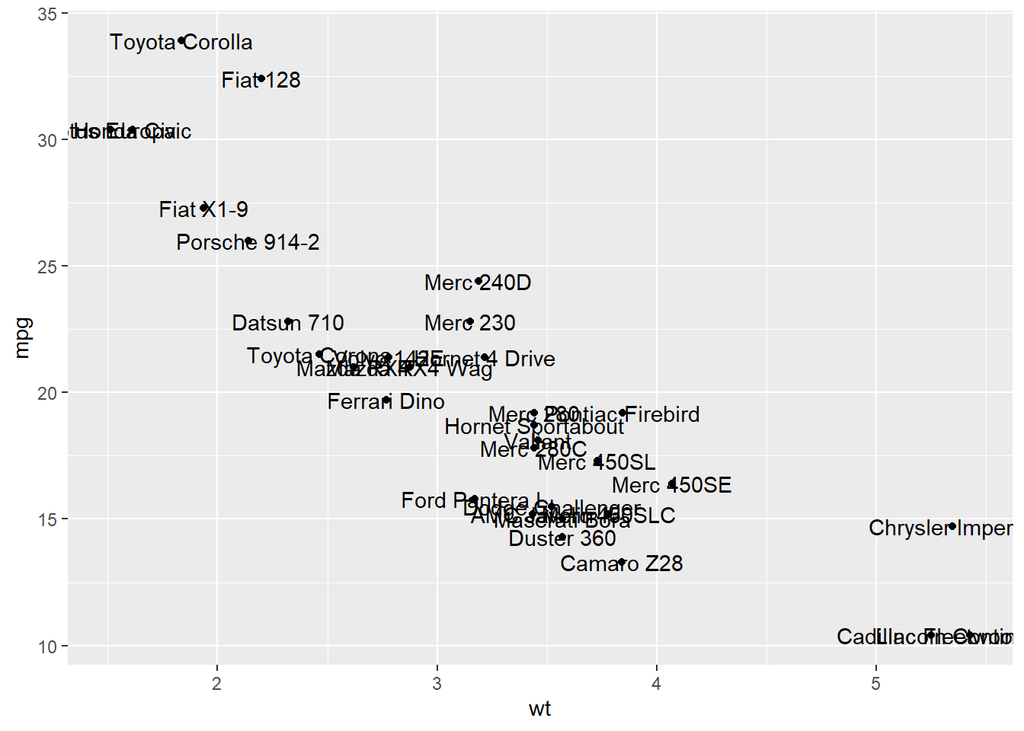

```r
ggplot(mtcars, aes(x=wt, y=mpg)) +
  geom_point() +
  geom_text(label=rownames(mtcars))
```

### Add regression lines

The functions below can be used to add regression lines to a scatter plot : geom_smooth(), stat_smooth(), geom_abline()

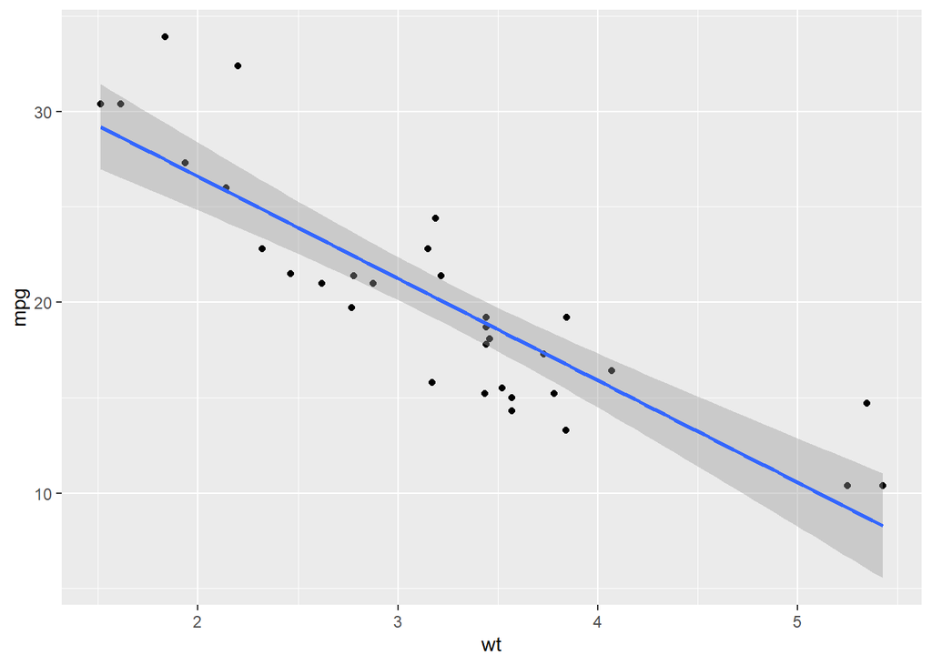

```r
# Add the regression line
ggplot(mtcars, aes(x=wt, y=mpg)) +
  geom_point()+
  geom_smooth(method=lm)
```

## GGally package

```r
library(GGally)
```

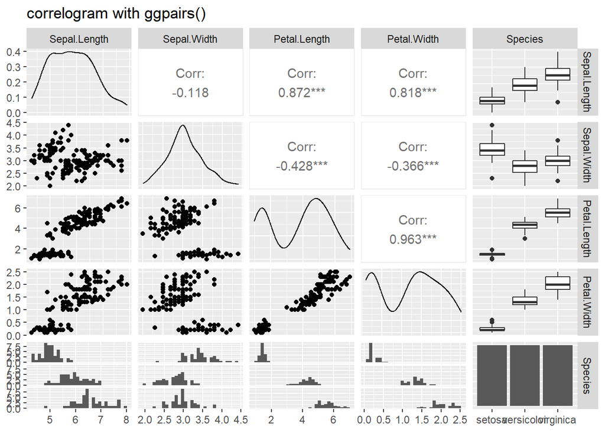

```r
ggpairs(iris, title="correlogram with ggpairs()")
```

## Correlational coefficients

Use cor()

```r
cor(iris[1:4])
```

```
##              Sepal.Length Sepal.Width Petal.Length Petal.Width
## Sepal.Length    1.0000000  -0.1175698    0.8717538   0.8179411
## Sepal.Width    -0.1175698   1.0000000   -0.4284401  -0.3661259
## Petal.Length    0.8717538  -0.4284401    1.0000000   0.9628654
## Petal.Width     0.8179411  -0.3661259    0.9628654   1.0000000
```

We see that Petal.Length and Petal.Width are highly correlated from the matrix plot and cor values

## Box plots

### Boxplot of MPG by Car Cylinders

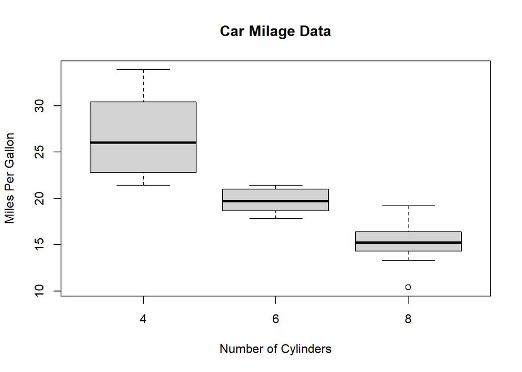

```r
data(mtcars)
boxplot(mpg~cyl,data=mtcars, main="Car Milage Data",
   xlab="Number of Cylinders", ylab="Miles Per Gallon")
```

Note: outlier on 8 cyl bottom

An outlier is an observation that is numerically distant from the rest of the data. When reviewing a boxplot, an outlier is defined as a data point that is located outside the fences (“whiskers”) of the boxplot (e.g: *** outside 1.5 times the interquartile range *** above the upper quartile and below the lower quartile). -> https://www.r-statistics.com/tag/boxplot-outlier/

### ggplot2 box plot

Reference

http://www.sthda.com/english/wiki/ggplot2-box-plot-quick-start-guide-r-software-and-data-visualization

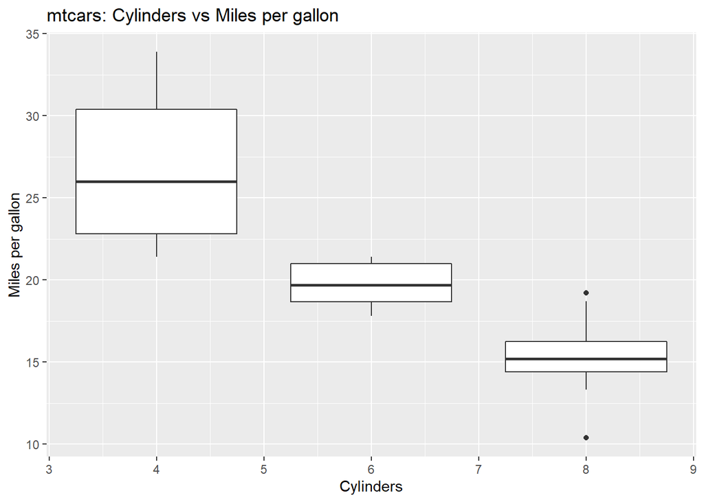

```r
ggplot(mtcars, aes(x =cyl, y=mpg, group = cyl)) + # object
  geom_boxplot() + # box plot
  ggtitle("mtcars: Cylinders vs Miles per gallon") +
# modify title, x , y label
  xlab('Cylinders') +
  ylab('Miles per gallon')
```